# wine数据集的异常点检测

```python
import pandas as pd
from sklearn import metrics
from scipy import interpolate
import numpy as np
import os
import csv
import collections
from sklearn.decomposition import PCA, KernelPCA
import matplotlib.pyplot as plt
from pyod.utils.utility import standardizer
from pyod.utils.data import evaluate_print
from pyod.utils.example import visualize
from pyod.models.pca import PCA
from pyod.models.knn import KNN
from pyod.models.lof import LOF
from pyod.models.abod import ABOD
from pyod.models.loda import LODA
from pyod.models.lscp import LSCP
from sklearn.datasets import make_classification
from pyod.models.combination import aom, moa, average, maximization
from pyod.utils.utility import precision_n_scores
import time
from sklearn.metrics import roc_auc_score
```

### 获取异常点比例

```python
data = pd.read_csv('data/wine/meta_data/meta_wine.csv')
```

```python
ar = data['anomaly.rate']
ar_level = data['anomaly.rate.level']
```

```python
set(ar_level)
```

```
{'ar-0', 'ar-1', 'ar-2', 'ar-3', 'ar-4', 'ar-6'}
```

```python
data_dic = collections.defaultdict(list)
for item in data.iterrows():
    data_dic[item[1]['anomaly.rate.level']].append(item[1]['bench.id'])
for item in data_dic:
    print(len(data_dic[item]))
```

```
300
180
190
180
180
180
```

```python
ar_mean = [np.mean(ar[:300]), np.mean(ar[300:480]), np.mean(ar[480:670]),
           np.mean(ar[670:850]), np.mean(ar[850:1030]), np.mean(ar[1030:1210])]
```

```python
ar_mean
```

```
[0.4124346847223457,
 0.0011470909950932406,
 0.005120850079917093,
 0.010155581545633015,
 0.05007634308372423,
 0.1001473472086161]
```

### 可以看到，数据集一共分为6个异常点比例等级，个数如上

```python
data = pd.read_csv('data/wine/benchmarks/wine_benchmark_0001.csv')
```

### 观察其中一个csv数据，选择特征属性

```python
data.head(5)
```

|  | point.id | motherset | origin | original.label | diff.score | ground.truth | fixed.acidity | volatile.acidity | citric.acid | residual.sugar | chlorides | free.sulfur.dioxide | total.sulfur.dioxide | density | pH | sulphates | alcohol |
| --- | --- | --- | --- | --- | --- | --- | --- | --- | --- | --- | --- | --- | --- | --- | --- | --- | --- |
| 0 | wine_point_3594 | wine | regression | 7 | 0.050492 | nominal | -1.245962 | -0.362411 | -0.265853 | -0.261304 | -0.343495 | 1.209882 | 0.747594 | -0.899276 | 0.817846 | -0.613338 | 0.174560 |
| 1 | wine_point_5089 | wine | regression | 5 | 0.082237 | anomaly | 0.759540 | 0.973867 | 0.215849 | -0.534540 | 0.598458 | -0.536656 | 0.199134 | 0.968217 | 0.071518 | 0.596292 | -0.915394 |
| 2 | wine_point_1912 | wine | regression | 6 | 0.290201 | nominal | -0.088942 | -0.969809 | -0.403482 | -0.870829 | -0.429127 | -0.592996 | -0.791633 | -0.699187 | -1.110168 | 1.402712 | -0.496181 |
| 3 | wine_point_4908 | wine | regression | 5 | 0.053559 | anomaly | 0.219597 | 0.973867 | 0.284664 | 0.138039 | 0.427194 | -0.762016 | -0.243173 | 1.034913 | 0.817846 | 1.805921 | 0.006874 |
| 4 | wine_point_2246 | wine | regression | 7 | 0.420300 | nominal | 0.219597 | -0.180191 | -0.541112 | 0.348220 | -0.714567 | -0.142276 | 0.446826 | -0.242318 | -0.363840 | -1.016548 | 0.090717 |

```python
data.columns
```

```
Index(['point.id', 'motherset', 'origin', 'original.label', 'diff.score',
       'ground.truth', 'fixed.acidity', 'volatile.acidity', 'citric.acid',
       'residual.sugar', 'chlorides', 'free.sulfur.dioxide',
       'total.sulfur.dioxide', 'density', 'pH', 'sulphates', 'alcohol'],
      dtype='object')
```

### 选择groundtruth之后的属性为特征

### 定义评估函数

```python
def evaluation(y, y_scores, method):
    '''
    评估函数，y为groundtruth，y_scores为预测值，返回PR曲线，ROC曲线和AUC
    '''
    if isinstance(y_scores, dict):
        colors = ['r', 'g', 'b', '#FF1493', '#483D8B']
        plt.figure(figsize=(7,7))
        i = 0
        for algo in y_scores:
            pre_scr = y_scores[algo]
            print(algo, pre_scr.shape)
            fpr_level = np.arange(0, 1, 0.01)
            fpr, tpr, threshold = metrics.roc_curve(y, pre_scr)
            interp = interpolate.interp1d(fpr, tpr)
            tpr_at_fpr = [interp(x) for x in fpr_level]
            roc_auc = metrics.auc(fpr, tpr)
            plt.plot(fpr, tpr, color=colors[i], label='%s ROC(area = %0.2f)' % (algo, roc_auc))
            i += 1
        plt.xlabel('FPR')
        plt.ylabel('TPR')
        plt.title('Models Compare' + '-ROC')
        plt.plot([0, 1], [0, 1], color='navy', linestyle='--')
        plt.legend(loc="lower right")
    else:
        fpr_level = np.arange(0, 1, 0.01)
        fpr, tpr, threshold = metrics.roc_curve(y, y_scores)
        interp = interpolate.interp1d(fpr, tpr)
        tpr_at_fpr = [interp(x) for x in fpr_level]
        roc_auc = metrics.auc(fpr, tpr)
        precision, recall, _ = metrics.precision_recall_curve(y, y_scores)
        pr_auc = round(precision_n_scores(y, y_scores), ndigits=4)
#         pr_auc_t = metrics.auc(recall, precision)
        plt.figure(figsize=(12,5))
        plt.subplot(1, 2, 1)
        plt.xlabel('FPR')
        plt.ylabel('TPR')
        plt.title(method + '-ROC')
        plt.plot([0, 1], [0, 1], color='navy', linestyle='--')
        plt.plot(fpr, tpr, color='r', label='ROC curve (area = %0.2f)' % roc_auc)
        plt.legend(loc="lower right")
        plt.subplot(1, 2, 2)
        plt.plot(recall, precision, marker='.', label='precision @ rank n: %0.2f)' % pr_auc)
        plt.legend(loc="upper right")
        plt.xlabel('Recall')
        plt.ylabel('Precision')
        plt.title(method + '-PR')
        plt.show()
```

### 对原始数据集进行抽样，每一个异常点level选择一个benchmark，共6个benchmark进行拼接，并读取groundturth和特征属性

```python
path = 'data/wine/benchmarks/'
samples = []
for item in data_dic:
    samples.append(data_dic[item][0])
y = []
x_train = []
contam = 0
for sample in samples:
    p = os.path.join(path, sample+'.csv')
    data = pd.read_csv(p)
    data = data.dropna()
    for i in data.iterrows():
        # 0为正常，1为异常点
        if i[1][5] == 'anomaly':
            y.append(1)
            contam += 1
        else:
            y.append(0)
        x_train.append(list(i[1][6:17]))
x_train = np.array(x_train)
y = np.array(y)
contam /= len(y)
```

```python
contam
```

```
0.08751529987760098
```

### 使用算法在抽样集合中进行离群点检测，该部分用到的算法分别为Proximity-Based(KNN，LOF)，Linear Model(PCA)，Outlier Ensembles(LODA)，算法组合（PCA+KNN）

```python
algorithms = ['KNN', 'LOF', 'PCA', 'LODA']
all_scores = {}
# all_scores = collections.defaultdict(list)
```

### 首先对比分析算法在同一个benchmark上的表现，这里我们选择抽样的6个数据集进行测试

### 1.KNN

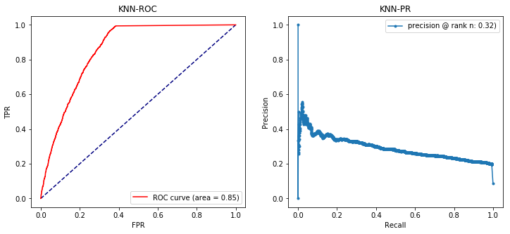

```python
clf_name = 'KNN'
clf = KNN(n_neighbors=5, contamination=contam)
x_train = standardizer(x_train)
clf.fit(x_train)
knn_y_pred = clf.labels_  # binary labels (0: inliers, 1: outliers)
knn_y_scores = clf.decision_scores_  # raw outlier scores
evaluation(y, knn_y_scores, clf_name)
all_scores['KNN'] = knn_y_scores
```

### 2.LOF

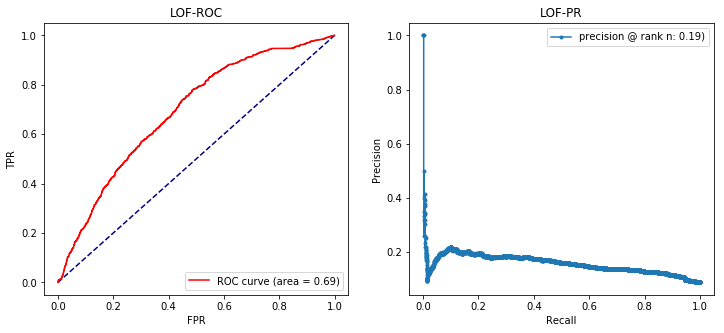

```python
clf_name = 'LOF'
clf = LOF(contamination=contam)
x_train = standardizer(x_train)
clf.fit(x_train)
y_pred = clf.labels_  # binary labels (0: inliers, 1: outliers)
y_scores = clf.decision_scores_  # raw outlier scores
evaluation(y, y_scores, clf_name)
all_scores['LOF'] = y_scores
```

### 3.PCA

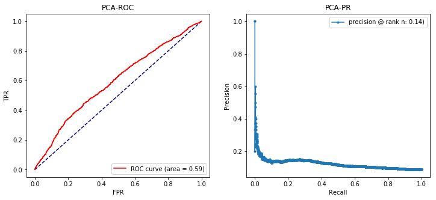

```python
clf_name = 'PCA'
clf = PCA(contamination=contam)
x_train = standardizer(x_train)
clf.fit(x_train)
y_pred = clf.labels_  # binary labels (0: inliers, 1: outliers)
y_scores = clf.decision_scores_  # raw outlier scores
evaluation(y, y_scores, clf_name)
all_scores['PCA'] = y_scores
```

### 4.LODA

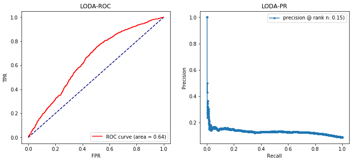

```python
clf_name = 'LODA'
clf = LODA(contamination=contam)
x_train = standardizer(x_train)
clf.fit(x_train)
y_pred = clf.labels_  # binary labels (0: inliers, 1: outliers)
y_scores = clf.decision_scores_  # raw outlier scores
evaluation(y, y_scores, clf_name)
all_scores['LODA'] = y_scores
```

### 5.PCA+KNN

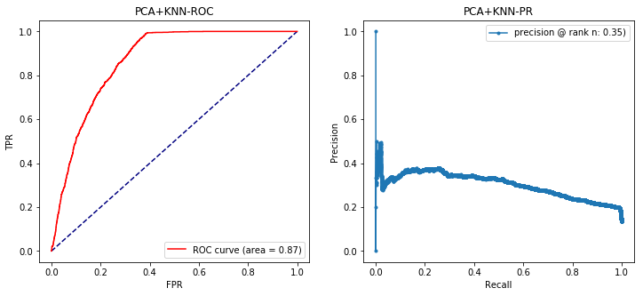

```python
pca = PCA(n_components=2)
kpca = KernelPCA(n_components=2, kernel="poly")
x_train_pca = kpca.fit_transform(x_train)
clf = KNN(n_neighbors=5, contamination=contam)
x_train_pca = standardizer(x_train_pca)
clf.fit(x_train_pca)
y_pred_pca = clf.labels_  # binary labels (0: inliers, 1: outliers)
y_scores = clf.decision_scores_  # raw outlier scores
evaluation(y, y_scores, 'PCA+KNN')
all_scores['PCA+KNN'] = y_scores
```

```
KNN (22876,)
LOF (22876,)
PCA (22876,)
LODA (22876,)
PCA+KNN (22876,)
```

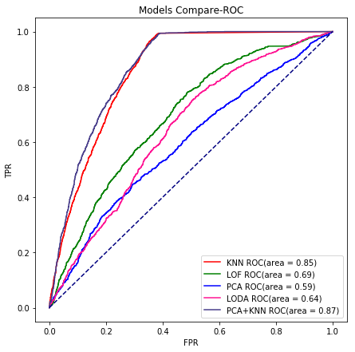

```python
evaluation(y, all_scores, algorithms)
```

### 可以看到，在同一个抽样的benchmark下，PCA+KNN表现最好，ROC-AUC达到了0.87，PCA表现最差，仅有0.59

### 对PCA+KNN进行可视化

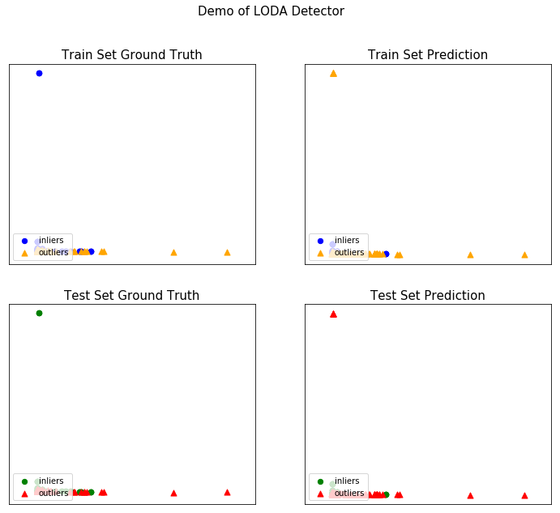

```python
visualize(clf_name, x_train_pca, y, x_train_pca, y, y_pred_pca, y_pred_pca,
         show_figure=True, save_figure=False)
```

### 上图为可视化结果，由于没有test集，因此train和test的结果相同。可以看到，对原始11维数据进行PCA降维之后，存在3个簇距离较远，因此其他簇显得比较集中。在3个较远的簇中，2个为异常值，1个为正常值（左上角），算法将其3个都判定为异常值（基于最近邻）。另外，观察集中分布的区域可以发现，算法将正常值识别为异常值的出现频率比将异常值识别为正常值的频率要高。

### 这里尝试对PCA降维后的数据进行判定函数可视化，由于数据量太大，进行抽样绘制

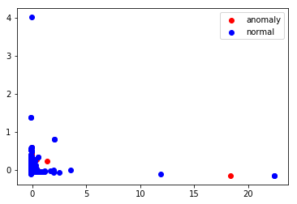

```python
visual_ano = [[], []]
visual_nor = [[], []]
for i in range(0, len(x_train_pca), 10):
    if y[i] == 1:
        visual_ano[0].append(x_train_pca[i][0])
        visual_ano[1].append(x_train_pca[i][1])
    else:
        visual_nor[0].append(x_train_pca[i][0])
        visual_nor[1].append(x_train_pca[i][1])
plt.scatter(visual_ano[0], visual_ano[1], c='r')
plt.scatter(visual_nor[0], visual_nor[1], c='b')
plt.legend(['anomaly', 'normal'])
plt.show()
```

### 可以看到，正常点和异常点分布仍比较耦合，说明PCA降维对异常点检测的贡献并不大，同时AUC也说明了这一点。

### 在所有样本上进行模型benchmark测试，输出auc到表格

```python
results = collections.defaultdict(list)
with open('results.csv', 'w', newline='', encoding='utf-8') as f:
    csv_writer = csv.writer(f)
    csv_writer.writerow(['benchmark_id', 'Model', 'ROC', 'precision at rank n', 'execution time'])
    for item in data_dic:
        for bench_id in data_dic[item]:
            x_item = []
            y_item = []
            contam = 0
            p = os.path.join(path, bench_id+'.csv')
            for i in pd.read_csv(p).iterrows():
                if i[1][5] == 'anomaly':
                    y_item.append(1)
                    contam += 1
                else:
                    y_item.append(0)
                x_item.append(list(i[1][6:17]))
            x_item = np.array(x_item)
            y_item = np.array(y_item)
            contam /= len(y_item)
            contam = min(0.5, contam)
            # 定义模型
            classifiers = {'KNN': KNN(contamination=contam),
                           'LOF': LOF(contamination=contam),
                           'PCA': PCA(contamination=contam),
                           'LODA': LODA(contamination=contam)
                          }
            for cls in classifiers:
                clf = classifiers[cls]
                t0 = time.time()
                x_item = standardizer(x_item)
                clf.fit(x_item)
                y_scores = clf.decision_function(x_item)
                t1 = time.time()
                duration = round(t1 - t0, ndigits=4)

                roc = round(roc_auc_score(y_item, y_scores), ndigits=4)
                prn = round(precision_n_scores(y_item, y_scores), ndigits=4)
                results[cls].append(roc)

                print('benchmark id:{bench_id}, model:{clf_name}, ROC:{roc}, precision @ rank n:{prn}, '
                      'execution time: {duration}s'.format(
                    bench_id=bench_id, clf_name=cls, roc=roc, prn=prn, duration=duration))

                csv_writer.writerow([bench_id, cls, roc, prn, duration])

f.close()
```

```
benchmark id:wine_benchmark_0001, model:KNN, ROC:0.5448, precision @ rank n:0.41, execution time: 0.4174s
benchmark id:wine_benchmark_0001, model:LOF, ROC:0.55, precision @ rank n:0.4063, execution time: 0.3313s
benchmark id:wine_benchmark_0001, model:PCA, ROC:0.5418, precision @ rank n:0.4171, execution time: 0.006s
benchmark id:wine_benchmark_0001, model:LODA, ROC:0.5297, precision @ rank n:0.3951, execution time: 0.038s
benchmark id:wine_benchmark_0002, model:KNN, ROC:0.5468, precision @ rank n:0.3961, execution time: 0.4434s
benchmark id:wine_benchmark_0002, model:LOF, ROC:0.5659, precision @ rank n:0.4028, execution time: 0.3503s
benchmark id:wine_benchmark_0002, model:PCA, ROC:0.5408, precision @ rank n:0.3943, execution time: 0.005s
benchmark id:wine_benchmark_0002, model:LODA, ROC:0.521, precision @ rank n:0.3695, execution time: 0.035s
benchmark id:wine_benchmark_0003, model:KNN, ROC:0.5582, precision @ rank n:0.4163, execution time: 0.4074s
benchmark id:wine_benchmark_0003, model:LOF, ROC:0.5552, precision @ rank n:0.4163, execution time: 0.3043s
benchmark id:wine_benchmark_0003, model:PCA, ROC:0.5358, precision @ rank n:0.4081, execution time: 0.006s
benchmark id:wine_benchmark_0003, model:LODA, ROC:0.5261, precision @ rank n:0.3941, execution time: 0.035s
benchmark id:wine_benchmark_0004, model:KNN, ROC:0.5486, precision @ rank n:0.4188, execution time: 0.4254s
benchmark id:wine_benchmark_0004, model:LOF, ROC:0.5547, precision @ rank n:0.4239, execution time: 0.3273s
benchmark id:wine_benchmark_0004, model:PCA, ROC:0.5512, precision @ rank n:0.4312, execution time: 0.0065s
benchmark id:wine_benchmark_0004, model:LODA, ROC:0.5463, precision @ rank n:0.4283, execution time: 0.0345s
benchmark id:wine_benchmark_0005, model:KNN, ROC:0.5563, precision @ rank n:0.4235, execution time: 0.4024s
benchmark id:wine_benchmark_0005, model:LOF, ROC:0.5648, precision @ rank n:0.413, execution time: 0.3018s
benchmark id:wine_benchmark_0005, model:PCA, ROC:0.5507, precision @ rank n:0.4205, execution time: 0.006s
benchmark id:wine_benchmark_0005, model:LODA, ROC:0.5657, precision @ rank n:0.4183, execution time: 0.039s
benchmark id:wine_benchmark_0006, model:KNN, ROC:0.5435, precision @ rank n:0.4227, execution time: 0.4214s
benchmark id:wine_benchmark_0006, model:LOF, ROC:0.5561, precision @ rank n:0.4205, execution time: 0.3273s
benchmark id:wine_benchmark_0006, model:PCA, ROC:0.5387, precision @ rank n:0.4312, execution time: 0.006s
benchmark id:wine_benchmark_0006, model:LODA, ROC:0.5363, precision @ rank n:0.4258, execution time: 0.039s
benchmark id:wine_benchmark_0007, model:KNN, ROC:0.5455, precision @ rank n:0.4223, execution time: 0.4184s
benchmark id:wine_benchmark_0007, model:LOF, ROC:0.5473, precision @ rank n:0.4133, execution time: 0.3013s
benchmark id:wine_benchmark_0007, model:PCA, ROC:0.5426, precision @ rank n:0.429, execution time: 0.005s
benchmark id:wine_benchmark_0007, model:LODA, ROC:0.6259, precision @ rank n:0.5007, execution time: 0.036s
benchmark id:wine_benchmark_0008, model:KNN, ROC:0.5563, precision @ rank n:0.4192, execution time: 0.4234s
benchmark id:wine_benchmark_0008, model:LOF, ROC:0.562, precision @ rank n:0.4165, execution time: 0.3338s
benchmark id:wine_benchmark_0008, model:PCA, ROC:0.5563, precision @ rank n:0.4162, execution time: 0.006s
benchmark id:wine_benchmark_0008, model:LODA, ROC:0.531, precision @ rank n:0.3954, execution time: 0.038s
benchmark id:wine_benchmark_0009, model:KNN, ROC:0.5466, precision @ rank n:0.4172, execution time: 0.3969s
benchmark id:wine_benchmark_0009, model:LOF, ROC:0.5435, precision @ rank n:0.401, execution time: 0.2943s
benchmark id:wine_benchmark_0009, model:PCA, ROC:0.5447, precision @ rank n:0.4216, execution time: 0.006s
benchmark id:wine_benchmark_0009, model:LODA, ROC:0.5098, precision @ rank n:0.4062, execution time: 0.035s
benchmark id:wine_benchmark_0010, model:KNN, ROC:0.5565, precision @ rank n:0.4119, execution time: 0.4489s
benchmark id:wine_benchmark_0010, model:LOF, ROC:0.5601, precision @ rank n:0.4085, execution time: 0.3523s
benchmark id:wine_benchmark_0010, model:PCA, ROC:0.5457, precision @ rank n:0.4186, execution time: 0.006s
benchmark id:wine_benchmark_0010, model:LODA, ROC:0.5279, precision @ rank n:0.3888, execution time: 0.044s
```

[output cut: 4785 more lines]

```
benchmark id:wine_benchmark_1677, model:LOF, ROC:0.5885, precision @ rank n:0.1407, execution time: 0.4634s
benchmark id:wine_benchmark_1677, model:PCA, ROC:0.5516, precision @ rank n:0.1432, execution time: 0.006s
benchmark id:wine_benchmark_1677, model:LODA, ROC:0.5888, precision @ rank n:0.1535, execution time: 0.049s
benchmark id:wine_benchmark_1678, model:KNN, ROC:0.5955, precision @ rank n:0.1599, execution time: 0.5415s
benchmark id:wine_benchmark_1678, model:LOF, ROC:0.5959, precision @ rank n:0.1316, execution time: 0.483s
benchmark id:wine_benchmark_1678, model:PCA, ROC:0.5426, precision @ rank n:0.1089, execution time: 0.009s
benchmark id:wine_benchmark_1678, model:LODA, ROC:0.5813, precision @ rank n:0.119, execution time: 0.047s
benchmark id:wine_benchmark_1679, model:KNN, ROC:0.5859, precision @ rank n:0.1603, execution time: 0.5251s
benchmark id:wine_benchmark_1679, model:LOF, ROC:0.5964, precision @ rank n:0.1454, execution time: 0.4884s
benchmark id:wine_benchmark_1679, model:PCA, ROC:0.5565, precision @ rank n:0.1279, execution time: 0.007s
benchmark id:wine_benchmark_1679, model:LODA, ROC:0.5455, precision @ rank n:0.1323, execution time: 0.048s
benchmark id:wine_benchmark_1680, model:KNN, ROC:0.5725, precision @ rank n:0.1739, execution time: 0.5425s
benchmark id:wine_benchmark_1680, model:LOF, ROC:0.5703, precision @ rank n:0.1535, execution time: 0.4489s
benchmark id:wine_benchmark_1680, model:PCA, ROC:0.5495, precision @ rank n:0.1282, execution time: 0.006s
benchmark id:wine_benchmark_1680, model:LODA, ROC:0.5931, precision @ rank n:0.1535, execution time: 0.045s
```

```python
ar_mean
```

[output not shown]

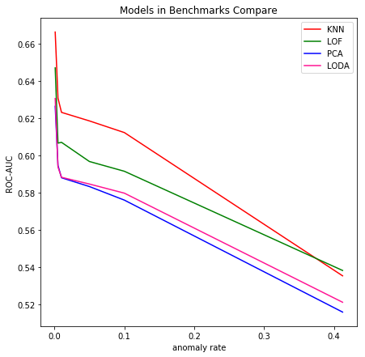

```python
ar_mean.sort()
plt.figure(figsize=(7,7))
plt.xlabel('anomaly rate')
plt.ylabel('ROC-AUC')
colors = ['r', 'g', 'b', '#FF1493', '#483D8B']
i = 0
for cls in classifiers:
    mean_y = [np.mean(results[cls][300:480]), np.mean(results[cls][480:670]), np.mean(results[cls][670:850]),
              np.mean(results[cls][850:1030]), np.mean(results[cls][1030:1210]), np.mean(results[cls][:300]), ]
    plt.plot(ar_mean, mean_y, color=colors[i], label=cls)
    i += 1
plt.title('Models in Benchmarks Compare')
plt.legend(loc="upper right")
plt.show()
```